### 8월/4주

#### ▶ 정당지지도

더불어민주당 44.2%, 국민의힘 35.1%, 조국혁신당 5.8%, 개혁신당 3.4%, 기타 정당 2.2%, 지지하는 정당 없다 8.6%, 잘 모르겠다 0.8%

#### ▶ 국정평가

잘하고 있다 31.7%, 잘못하고 있다 65.7%, 잘 모르겠다 2.6%

#### ☑ 김경수 전지사 정치활동 재개 찬반

매우 찬성한다 23.7%, 대체로 찬성하는 편이다 22.0%, 대체로 반대하는 편이다 15.5%, 매우 반대한다 27.6%, 잘 모르겠다 11.1%

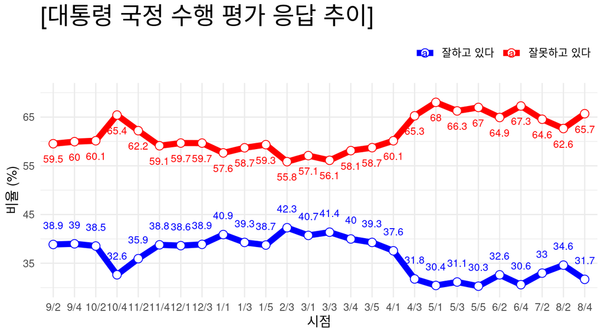

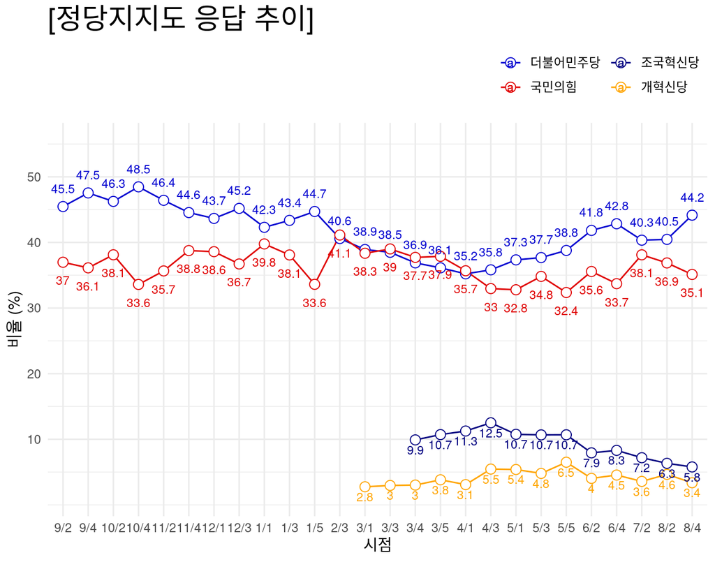

### 추가사항

- [주요질문 / 집단별 세부통계 보기](https://modernity.shinyapps.io/survey_str/) (링크누르시오)

### 참고사항

- 표본수: 2,006명,표본오차는 95% ±2.2%p
- 조사정보: 스트레이트뉴스의 의뢰로 조원씨앤아이가 2024년 8월 17일~19일 3일간

  전국 만 18세 이상 남녀를 대상으로 ARS 여론조사

  (휴대전화 100% RDD 방식, 성,연령대,지역별 비례할당 후 무작위 추출)를 실시한 결과이며,

  표본수는 2,006(총 통화시도 80,999명, 응답률 2.5%)

  ※ 가중치 부여 방식: [림가중] 성별, 연령별, 지역별 가중값 부여(2024년 7월말 행정안전부 발표 주민등록인구기준)
- [중앙선거여론조사심의위원회](https://nesdc.go.kr/portal/bbs/B0000005/list.do?menuNo=200467)에서 관련사항 확인가능

2024.08.20 (화) 17:00 제작

- 연구개발 단계입니다.
- 제공: 감동과 마음의 [조원씨앤아이](http://jowoncni.com/html/index.html)